# From relative-abundance profiles to microbial community composition over time

Computational 16S practical — EMBO Microbial Communities 2026

Fabian Springer

7 October 2026

# 1 Learning objectives

By the end of this practical, you should be able to:

1. inspect and validate a taxonomic relative-abundance table;
2. reshape sparse taxonomic results into a complete sample-by-taxon matrix;
3. visualize and interpret community composition while accounting for the compositional nature of relative-abundance data;
4. calculate and interpret observed species-level assignment richness and Shannon diversity;
5. compare samples using Bray–Curtis dissimilarity and principal coordinate analysis (PCoA); and
6. examine longitudinal changes in species-level relative abundances across experimental conditions and biological replicates.

> **Practical scope.** Taxonomic classification has already been run. We start from the combined NanoCLUST relative-abundance output so that the session can focus on interpretation rather than waiting for a sequencing pipeline.

# 2 Experimental design and input data

The prepared dataset contains 18 samples. Axenic and xenic cultures were sampled at `T00`, `T02`, `T07`, and `T14`, with two biological replicates per condition and timepoint. Two media controls are available at `T00` only.

The NanoCLUST table contains classified relative-abundance profiles at order, family, genus, and species rank. It does not contain raw sequencing reads or per-sample read counts. Taxonomic names should therefore be interpreted as classifier assignments rather than confirmed organism identities.

Before loading the taxonomic profiles, import the cleaned experimental sample sheet. Its `Sample_ID` column contains the barcode identifier used by the NanoCLUST output.

```r
stopifnot(file.exists(prepared_metadata_path))

experimental_metadata_df <- read_tsv(
  prepared_metadata_path,
  show_col_types = FALSE,
  progress = FALSE
)

stopifnot(
  all(
    c(
      "Sample_ID",
      "embl_id",
      "axenic_xenic_media",
      "timepoint_d",
      "replicate"
    ) %in% names(experimental_metadata_df)
  ),
  !anyNA(experimental_metadata_df$Sample_ID),
  !anyDuplicated(experimental_metadata_df$Sample_ID)
)

sample_meta_df <- experimental_metadata_df %>%
  mutate(
    condition = axenic_xenic_media,
    condition = factor(condition, levels = c("Axenic", "Xenic", "Media")),
    timepoint = parse_number(timepoint_d),
    replicate = factor(replicate),
    sample_label = str_c(
      "T",
      timepoint,
      "_",
      str_to_lower(as.character(replicate))
    )
  ) %>%
  select(
    Sample_ID,
    sample_label,
    condition,
    timepoint,
    replicate,
    everything()
  )

stopifnot(
  nrow(sample_meta_df) == 18,
  !anyNA(
    sample_meta_df[
      c(
        "Sample_ID",
        "sample_label",
        "condition",
        "timepoint",
        "replicate"
      )
    ]
  ),
  !anyDuplicated(sample_meta_df$Sample_ID),
  !anyDuplicated(sample_meta_df[c("condition", "sample_label")])
)
```

# 3 Load and inspect the NanoCLUST output

The input contains one taxonomic assignment per sample and taxonomic rank. `tax` uses the codes `O`, `F`, `G`, and `S` for order, family, genus, and species.

```r
stopifnot(file.exists(abundance_path))

abundance_raw_df <- read_csv(
  abundance_path,
  show_col_types = FALSE,
  progress = FALSE
)

required_columns <- c("sample", "tax", "taxid", "rel_abundance")
stopifnot(all(required_columns %in% names(abundance_raw_df)))

abundance_df <- abundance_raw_df %>%
  transmute(
    Sample_ID = sample %>%
      str_remove("^rel_abundance_") %>%
      str_remove("_concat$"),
    tax_rank = tax,
    taxon = taxid,
    rel_abundance = as.numeric(rel_abundance)
  )

stopifnot(
  !anyNA(abundance_df),
  !anyDuplicated(abundance_df[c("Sample_ID", "tax_rank", "taxon")]),
  setequal(sample_meta_df$Sample_ID, abundance_df$Sample_ID),
  setequal(expected_tax_ranks, abundance_df$tax_rank),
  all(abundance_df$rel_abundance >= 0),
  all(abundance_df$rel_abundance <= 1)
)
```

Before plotting, summarize the object rather than printing all rows.

```r
rank_labels <- c(O = "Order", F = "Family", G = "Genus", S = "Species")

input_summary_df <- abundance_df %>%
  group_by(tax_rank) %>%
  summarise(
    rank = unname(rank_labels[first(tax_rank)]),
    samples = n_distinct(Sample_ID),
    unique_taxa = n_distinct(taxon),
    .groups = "drop"
  ) %>%
  select(rank, everything(), -tax_rank)

knitr::kable(input_summary_df)
```

| rank | samples | unique_taxa |
| --- | --- | --- |
| Family | 18 | 13 |
| Genus | 18 | 17 |
| Order | 18 | 12 |
| Species | 18 | 18 |

## 3.1 Check that each profile sums to one

Relative-abundance profiles should sum to one separately for every sample and rank.

```r
profile_sum_df <- abundance_df %>%
  group_by(Sample_ID, tax_rank) %>%
  summarise(profile_sum = sum(rel_abundance), .groups = "drop")

stopifnot(all(abs(profile_sum_df$profile_sum - 1) < sum_tolerance))

profile_sum_df %>%
  summarise(
    profiles_checked = n(),
    minimum_sum = min(profile_sum),
    maximum_sum = max(profile_sum)
  ) %>%
  knitr::kable(digits = 6)
```

| profiles_checked | minimum_sum | maximum_sum |
| --- | --- | --- |
| 72 | 1 | 1 |

**Discuss:** What information can we check in a relative-abundance table? What information has already been lost compared with the raw read counts?

# 4 Choose a taxonomic rank and complete missing combinations

We use species-level assignments for this practical because full-length Nanopore 16S reads can provide fine taxonomic resolution. Species labels are still hypotheses: classification depends on sequence quality, the reference database, conserved 16S regions, and the classifier.

The input is sparse: a taxon absent from a sample has no row. For plotting and distance calculations, we explicitly complete those missing sample–taxon combinations with zero.

```r
analysis_df <- abundance_df %>%
  filter(tax_rank == selected_rank) %>%
  select(Sample_ID, taxon, rel_abundance) %>%
  complete(Sample_ID, taxon, fill = list(rel_abundance = 0))

stopifnot(
  !anyNA(analysis_df),
  !anyDuplicated(analysis_df[c("Sample_ID", "taxon")])
)

completed_sum_df <- analysis_df %>%
  group_by(Sample_ID) %>%
  summarise(profile_sum = sum(rel_abundance), .groups = "drop")

stopifnot(all(abs(completed_sum_df$profile_sum - 1) < sum_tolerance))
```

# 5 Which organisms dominate the profiles?

A stacked bar chart gives an intuitive first view. To keep the legend readable, the ten most abundant taxa across all samples are shown individually and the remainder are grouped as `Other taxa`.

```r
taxon_summary_df <- analysis_df %>%
  group_by(taxon) %>%
  summarise(
    mean_abundance = mean(rel_abundance),
    maximum_abundance = max(rel_abundance),
    prevalence = mean(rel_abundance > 0),
    .groups = "drop"
  ) %>%
  arrange(desc(mean_abundance))

top_taxa <- taxon_summary_df %>%
  slice_head(n = top_n_taxa) %>%
  pull(taxon)

sample_order <- sample_meta_df %>%
  arrange(condition, timepoint, replicate, sample_label) %>%
  pull(Sample_ID)

composition_df <- analysis_df %>%
  left_join(
    sample_meta_df %>% select(Sample_ID, sample_label, condition),
    by = "Sample_ID"
  ) %>%
  mutate(
    display_taxon = if_else(taxon %in% top_taxa, taxon, "Other taxa"),
    Sample_ID = factor(Sample_ID, levels = sample_order)
  ) %>%
  group_by(condition, Sample_ID, sample_label, display_taxon) %>%
  summarise(rel_abundance = sum(rel_abundance), .groups = "drop")

display_levels <- c(top_taxa, "Other taxa")
taxon_colors <- setNames(
  c(RColorBrewer::brewer.pal(length(top_taxa), "Paired"), "grey70"),
  display_levels
)

composition_df <- composition_df %>%
  mutate(display_taxon = factor(display_taxon, levels = rev(display_levels)))
```

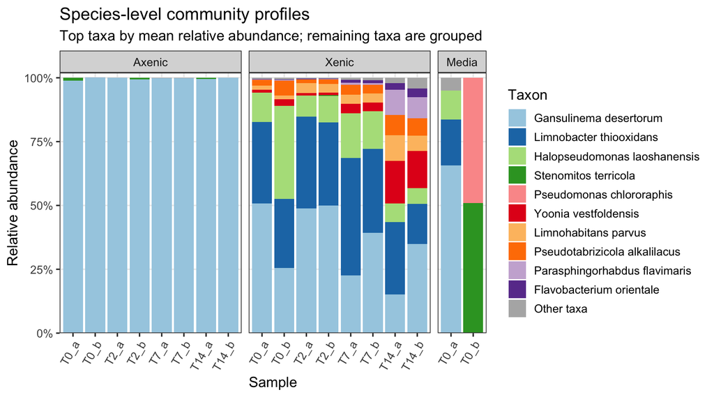

```r
composition_plot <- ggplot(
  composition_df,
  aes(x = Sample_ID, y = rel_abundance, fill = display_taxon)
) +
  geom_col(width = 0.9) +
  facet_grid(~condition, scales = "free_x", space = "free_x") +
  scale_fill_manual(values = taxon_colors, breaks = display_levels) +
  scale_x_discrete(
    labels = setNames(sample_meta_df$sample_label, sample_meta_df$Sample_ID)
  ) +
  scale_y_continuous(labels = label_percent(), expand = expansion(mult = c(0, 0.02))) +
  labs(
    title = "Species-level community profiles",
    subtitle = "Top taxa by mean relative abundance; remaining taxa are grouped",
    x = "Sample",
    y = "Relative abundance",
    fill = "Taxon"
  ) +
  theme_bw(base_size = 13) +
  theme(
    axis.text.x = element_text(angle = 60, hjust = 1),
    panel.grid.minor = element_blank()
  )

composition_plot
```

## 5.1 Stop here and discuss

Before continuing, examine the species-composition plot.

- Is this community composition what you expected?
- Which assignment dominates the axenic samples?
- What kind of organism is *Gansulinema desertorum*?
- Why do we not see *Chaetoceros neogracilis*, even though the diatom is present in every culture sample?
- Why might a cyanobacterial 16S sequence be amplified from a eukaryotic alga?
- What additional evidence would you need to confirm the origin of these reads?

**Discussion**

*Chaetoceros neogracilis* is a eukaryotic diatom and would normally be identified using a eukaryotic marker such as 18S rRNA. Its chloroplast, however, is evolutionarily derived from cyanobacteria and contains a 16S rRNA gene that can be amplified by bacterial 16S primers.

The NCBI reference database used by NanoCLUST contains bacterial and archaeal 16S sequences, but no *Chaetoceros* or other eukaryotic algal references. *Gansulinema desertorum* is a cyanobacterium. A plausible explanation is therefore that chloroplast-derived reads are being assigned to the closest available cyanobacterial reference.

The abundance pattern supports this interpretation, especially in the axenic samples, but does not prove it. Confirmation would require examining the read sequences and their alignments against suitable chloroplast references.

## 5.2 A note on compositional data

Every sample sums to 100%. If one taxon doubles while all absolute cell counts remain unchanged, the relative abundance of every other taxon must fall. Therefore, relative abundance alone cannot tell us whether a taxon grew, declined, or merely changed relative to another organism.

# 6 Calculating and visualizing alpha diversity

Alpha diversity describes the diversity within one sample. Here we calculate two complementary species-level metrics:

- **Observed species-level assignment richness** is the number of assignments with relative abundance greater than zero. (“How many distinct species-level assignments were reported?”)
- **Shannon diversity** increases when a sample contains more unique taxa and when their relative abundances are more even. (“How diverse is the community composition?”)

These are descriptive values calculated from the supplied classified relative abundances. Without raw read counts, we cannot evaluate sequencing depth, rarefy profiles to a common depth, or distinguish a true absence from an assignment below the detection threshold.

```r
# convert to matrix
species_mat <- analysis_df %>%
  pivot_wider(names_from = taxon, values_from = rel_abundance) %>%
  arrange(match(Sample_ID, sample_order)) %>%
  column_to_rownames("Sample_ID") %>%
  as.matrix()

stopifnot(
  is.numeric(species_mat),
  !anyNA(species_mat),
  all(species_mat >= 0),
  all(abs(rowSums(species_mat) - 1) < sum_tolerance),
  identical(rownames(species_mat), sample_order)
)

# generate output dataframe with observed richness and Shannon diversity
alpha_diversity_df <- tibble(
  Sample_ID = rownames(species_mat),
  observed_richness = rowSums(species_mat > 0),
  shannon_diversity = vegan::diversity(species_mat, index = "shannon")
) %>%
  left_join(
    sample_meta_df %>%
      select(Sample_ID, condition, timepoint, replicate),
    by = "Sample_ID"
  )

stopifnot(
  nrow(alpha_diversity_df) == nrow(sample_meta_df),
  !anyNA(alpha_diversity_df),
  !anyDuplicated(alpha_diversity_df$Sample_ID),
  all(is.finite(alpha_diversity_df$shannon_diversity)),
  all(alpha_diversity_df$observed_richness > 0)
)
```

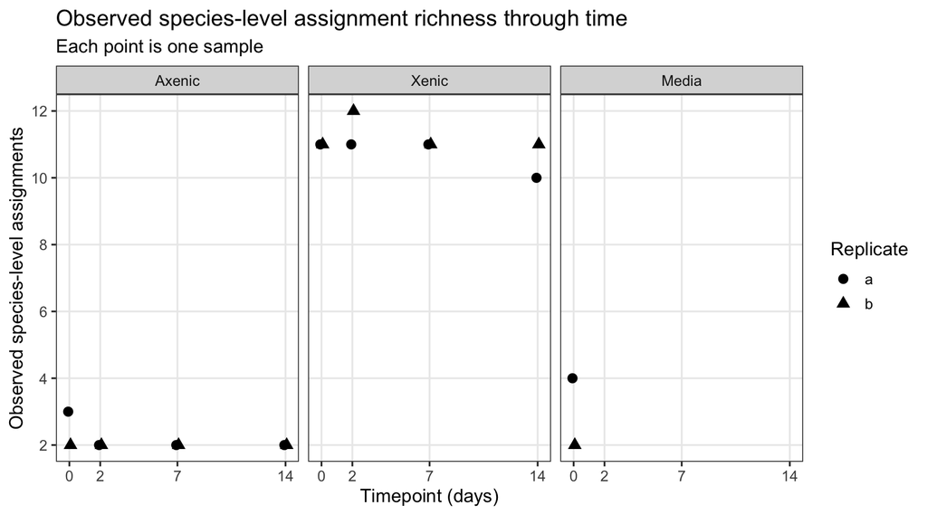

```r
ggplot(
  alpha_diversity_df,
  aes(
    x = timepoint,
    y = observed_richness,
    shape = replicate,
    group = replicate
  )
) +
  geom_point(size = 3, position = position_dodge(width = 0.3)) +
  facet_wrap(~condition) +
  scale_x_continuous(breaks = sort(unique(alpha_diversity_df$timepoint))) +
  scale_y_continuous(breaks = breaks_pretty()) +
  labs(
    title = "Observed species-level assignment richness through time",
    subtitle = "Each point is one sample",
    x = "Timepoint (days)",
    y = "Observed species-level assignments",
    shape = "Replicate"
  ) +
  theme_bw(base_size = 13) +
  theme(panel.grid.minor = element_blank())
```

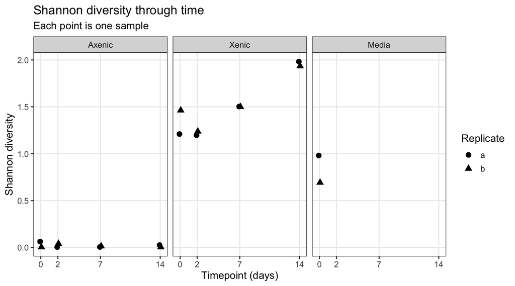

```r
ggplot(
  alpha_diversity_df,
  aes(
    x = timepoint,
    y = shannon_diversity,
    shape = replicate,
    group = replicate
  )
) +
  geom_point(size = 3, position = position_dodge(width = 0.3)) +
  facet_wrap(~condition) +
  scale_x_continuous(breaks = sort(unique(alpha_diversity_df$timepoint))) +
  labs(
    title = "Shannon diversity through time",
    subtitle = "Each point is one sample",
    x = "Timepoint (days)",
    y = "Shannon diversity",
    shape = "Replicate"
  ) +
  theme_bw(base_size = 13) +
  theme(panel.grid.minor = element_blank())
```

**Discuss:** Do richness and Shannon diversity tell the same story? Which metric changes when a sample has the same number of assignments but becomes dominated by one of them? Are replicate patterns consistent within each condition?

# 7 Compare complete communities with Bray–Curtis dissimilarity (beta diversity)

Bray–Curtis dissimilarity compares the complete abundance profiles of two samples. It is zero for identical profiles and approaches one as profiles become increasingly different.

```r
# Compute a pairwise distance matrix
bray_distance <- vegdist(species_mat, method = "bray")

# Compute principal coordinates (PCoA) from the distance matrix. Unlike PCA,
# PCoA can represent relationships defined by a non-Euclidean dissimilarity
# such as Bray–Curtis.
pcoa_fit <- cmdscale(bray_distance, k = 2, eig = TRUE, add = TRUE)

positive_eigenvalues <- pcoa_fit$eig[pcoa_fit$eig > 0]
axis_variance <- 100 * pcoa_fit$eig[1:2] / sum(positive_eigenvalues)

pcoa_df <- as_tibble(pcoa_fit$points, rownames = "Sample_ID") %>%
  rename(PCo1 = V1, PCo2 = V2) %>%
  left_join(
    sample_meta_df %>%
      select(Sample_ID, sample_label, condition),
    by = "Sample_ID"
  )

stopifnot(
  nrow(pcoa_df) == nrow(sample_meta_df),
  !anyNA(pcoa_df[c("Sample_ID", "sample_label", "condition")])
)

condition_levels <- levels(pcoa_df$condition)
condition_colors <- setNames(
  colorRampPalette(RColorBrewer::brewer.pal(8, "Dark2"))(
    length(condition_levels)
  ),
  condition_levels
)
```

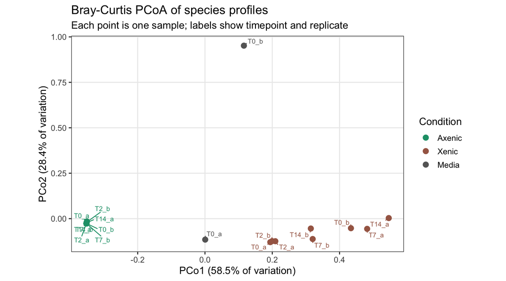

```r
pcoa_plot <- ggplot(pcoa_df, aes(PCo1, PCo2, color = condition)) +
  geom_point(size = 3) +
  geom_text_repel(
    aes(label = sample_label),
    size = 3,
    max.overlaps = 20,
    min.segment.length = 0,
    seed = 420
  ) +
  scale_color_manual(values = condition_colors) +
  labs(
    title = "Bray-Curtis PCoA of species profiles",
    subtitle = "Each point is one sample; labels show timepoint and replicate",
    x = paste0("PCo1 (", round(axis_variance[1], 1), "% of variation)"),
    y = paste0("PCo2 (", round(axis_variance[2], 1), "% of variation)"),
    color = "Condition"
  ) +
  theme_bw(base_size = 13) +
  theme(
    aspect.ratio = 0.65,
    panel.grid.minor = element_blank()
  )

pcoa_plot
```

The media controls are compositionally distinct from the culture samples and strongly influence the ordination. In particular, one media-control replicate lies far from all other samples along PCoA2. To see how such samples can affect the displayed axes, repeat the complete distance calculation and PCoA after restricting the analysis to the axenic and xenic cultures. Filtering points from the previous plot would not be equivalent because the media controls would still have influenced the fitted coordinates.

```r
culture_sample_meta_df <- sample_meta_df %>%
  filter(condition %in% c("Axenic", "Xenic")) %>%
  mutate(condition = droplevels(condition))

culture_species_mat <- species_mat[culture_sample_meta_df$Sample_ID, , drop = FALSE]

stopifnot(
  identical(rownames(culture_species_mat), culture_sample_meta_df$Sample_ID),
  all(abs(rowSums(culture_species_mat) - 1) < sum_tolerance),
  identical(levels(culture_sample_meta_df$condition), c("Axenic", "Xenic"))
)

culture_bray_distance <- vegdist(culture_species_mat, method = "bray")
culture_pcoa_fit <- cmdscale(
  culture_bray_distance,
  k = 2,
  eig = TRUE,
  add = TRUE
)

culture_positive_eigenvalues <- culture_pcoa_fit$eig[
  culture_pcoa_fit$eig > 0
]
culture_axis_variance <- 100 * culture_pcoa_fit$eig[1:2] /
  sum(culture_positive_eigenvalues)

culture_pcoa_df <- as_tibble(
  culture_pcoa_fit$points,
  rownames = "Sample_ID"
) %>%
  rename(PCo1 = V1, PCo2 = V2) %>%
  left_join(
    culture_sample_meta_df %>%
      select(Sample_ID, sample_label, condition),
    by = "Sample_ID"
  )

stopifnot(
  nrow(culture_pcoa_df) == nrow(culture_sample_meta_df),
  !anyNA(culture_pcoa_df[c("Sample_ID", "sample_label", "condition")])
)
```

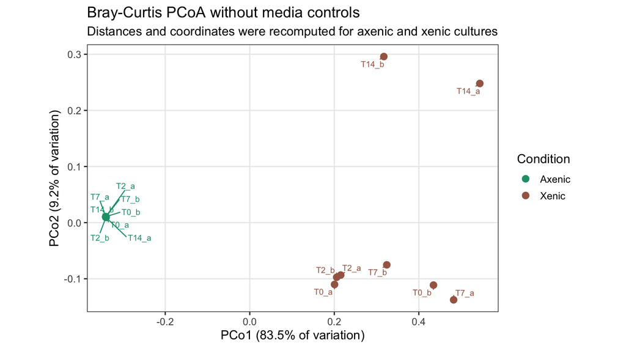

```r
culture_pcoa_plot <- ggplot(
  culture_pcoa_df,
  aes(PCo1, PCo2, color = condition)
) +
  geom_point(size = 3) +
  geom_text_repel(
    aes(label = sample_label),
    size = 3,
    max.overlaps = 20,
    min.segment.length = 0,
    seed = 420
  ) +
  scale_color_manual(
    values = condition_colors[levels(culture_sample_meta_df$condition)]
  ) +
  labs(
    title = "Bray-Curtis PCoA without media controls",
    subtitle = "Distances and coordinates were recomputed for axenic and xenic cultures",
    x = paste0("PCo1 (", round(culture_axis_variance[1], 1), "% of variation)"),
    y = paste0("PCo2 (", round(culture_axis_variance[2], 1), "% of variation)"),
    color = "Condition"
  ) +
  theme_bw(base_size = 13) +
  theme(
    aspect.ratio = 0.65,
    panel.grid.minor = element_blank()
  )

culture_pcoa_plot
```

**Discuss:** How does removing the compositionally distinct media controls change the apparent separation among culture samples? Which samples are similar? Do the clusters reflect condition, time, sequencing artefacts, or host-associated signal? How does this match what we saw in the barplot with the most abundant taxa?

# 8 Follow abundant taxa through time

Now we want to focus on individual taxa: How does the relative abundance of the most abundant taxa change over time?

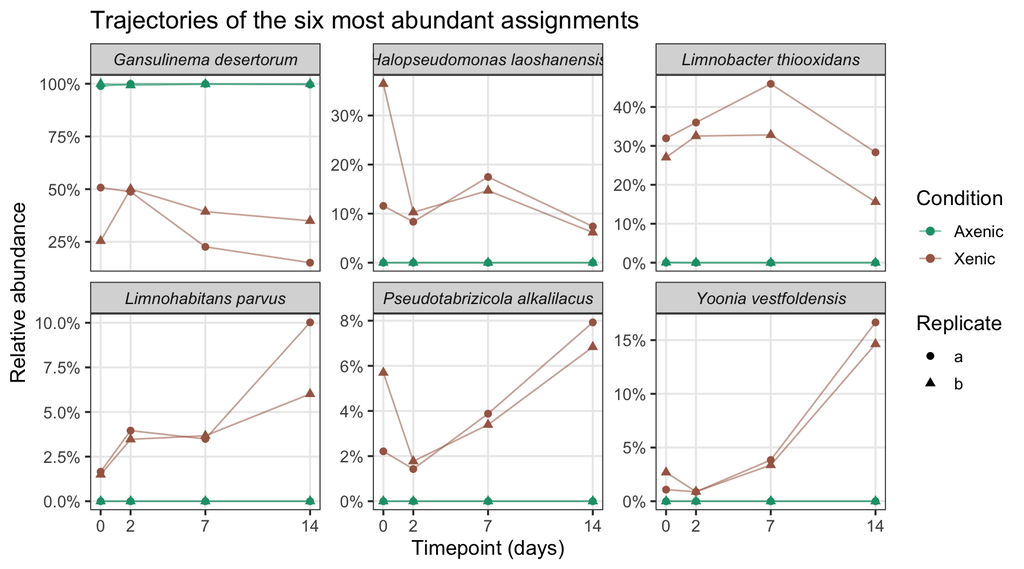

```r
time_course_analysis_df <- analysis_df %>%
  semi_join(
    culture_sample_meta_df %>% select(Sample_ID),
    by = "Sample_ID"
  )

time_course_taxa <- time_course_analysis_df %>%
  group_by(taxon) %>%
  summarise(mean_abundance = mean(rel_abundance), .groups = "drop") %>%
  arrange(desc(mean_abundance)) %>%
  slice_head(n = 6) %>%
  pull(taxon)

time_course_df <- time_course_analysis_df %>%
  filter(taxon %in% time_course_taxa) %>%
  left_join(culture_sample_meta_df, by = "Sample_ID")

stopifnot(
  setequal(unique(time_course_df$condition), c("Axenic", "Xenic")),
  !anyNA(time_course_df[c("Sample_ID", "condition", "timepoint", "replicate")])
)

ggplot(
  time_course_df,
  aes(
    x = timepoint,
    y = rel_abundance,
    color = condition,
    group = interaction(condition, replicate)
  )
) +
  geom_line(alpha = 0.55) +
  geom_point(aes(shape = replicate), size = 2) +
  facet_wrap(~taxon, scales = "free_y") +
  scale_x_continuous(breaks = sort(unique(time_course_df$timepoint))) +
  scale_color_manual(
    values = condition_colors[levels(culture_sample_meta_df$condition)]
  ) +
  scale_y_continuous(labels = label_percent()) +
  labs(
    title = "Trajectories of the six most abundant assignments",
    x = "Timepoint (days)",
    y = "Relative abundance",
    color = "Condition",
    shape = "Replicate"
  ) +
  theme_bw(base_size = 13) +
  theme(
    panel.grid.minor = element_blank(),
    strip.text = element_text(face = "italic")
  )
```

**Discuss:** Do all taxa follow similar trajectories? If not, what could explain the differences? How does the compositional nature of the data affect your interpretation?

# 9 Main findings and interpretation

The analyses reveal clear differences between the axenic and xenic cultures, as well as changes within the xenic cultures over time.

## 9.1 Main findings

- All eight axenic samples are dominated by the assignment *Gansulinema desertorum*, with a mean relative abundance of 99.7%. Their observed richness is only two or three assignments, and their Shannon diversity is close to zero.
- The xenic samples contain 10–12 assignments and have much higher Shannon diversity than the axenic samples. Their mean richness remains stable over time, whereas mean Shannon diversity changes from 1.34 at T0 to 1.22 at T2, 1.50 at T7, and 1.96 at T14. The later xenic profiles are therefore more even, rather than richer in detected assignments.
- The dominant assignments in the xenic cultures change over time. At T0, *Gansulinema desertorum*, *Limnobacter thiooxidans*, and *Halopseudomonas laoshanensis* account for most of the mean relative abundance. At T7, *Limnobacter thiooxidans* has the highest mean abundance (39.4%). By T14, *Gansulinema desertorum* and *Limnobacter thiooxidans* decrease to 25.0% and 22.0%, and *Yoonia vestfoldensis* is the third most abundant assignment at 15.6%.
- In the culture-only PCoA, the axenic and xenic samples separate along PCoA1. The axenic samples form a tight group, whereas the xenic samples are more dispersed and the T14 xenic samples shift along PCoA2.
- The two media controls differ strongly from one another. One lies far from all culture samples and strongly affects the PCoA when the controls are included.

## 9.2 What the current data cannot show

- The relative-abundance table does not contain read counts or quality metrics, so we cannot assess sequencing depth, classification yield, detection limits, or count-standardized diversity.
- Relative abundance cannot show whether a taxon increased or decreased in absolute abundance because every sample profile sums to 100%.
- Species-level classifier labels do not confirm that the named organisms were present. In particular, the dominant cyanobacterial assignment in the axenic cultures may represent chloroplast-derived 16S reads from the diatom.
- These exploratory plots do not test time or condition effects, establish causal relationships, or provide a media-control time course.

## 9.3 Biological interpretation and discussion

The axenic cultures remain almost exclusively dominated by the *Gansulinema desertorum* assignment throughout the experiment. In contrast, the xenic cultures have richer classified profiles in which relative abundances change and become more even at later timepoints. This pattern is consistent with changing community composition, but relative abundance alone cannot reveal whether individual populations grew or declined. The putative chloroplast origin of the dominant axenic assignment also remains a hypothesis that would require sequence-level confirmation.

- Why might a diatom culture produce a cyanobacterial 16S assignment?
- Why does Shannon diversity increase from T2 to T14 while observed richness remains almost unchanged?
- Which temporal patterns are similar between replicates, and where do the replicates differ?
- Which additional measurements would allow us to confirm the taxonomic assignments and distinguish relative changes from absolute population changes?

# 10 Further steps (optional)

## 10.1 Compare other taxonomic ranks

Change `selected_rank` near the beginning of the document from species (`S`) to genus (`G`) and rerun the analysis.

- Which composition and ordination patterns remain stable?
- Which apparent differences depend on the selected taxonomic rank?
- Why might genus-level assignments be more reliable for some 16S reads?

## 10.2 Compute changes in relative abundance from baseline

- In the axenic samples, combine the two biological replicates by calculating the mean relative abundance for each timepoint and species-level assignment.
- For each later timepoint, subtract the mean relative abundance at `T00` and express the result as a percentage-point change. Which assignments show the largest positive or negative changes?
- Why does a positive percentage-point change not prove that the corresponding organism increased in absolute abundance?